# QE2-final slides

### Learning Non-Stationary Space-Time Models for Environmental Monitoring (NOSTILL-GP)

### AAAI 2012

#### Sahil Garg, Amarjeet Singh and Fabio Ramos

#### Presenter: Zeel B Patel

### Introduction

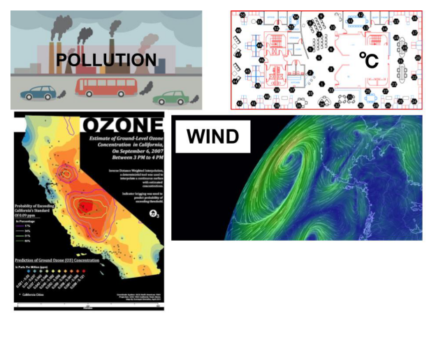

1. Gaussian processes (GP)
2. NOSTILL-GP (**NO**n-stationary **S**pace-**TI**me **L**atent **L**engthscale **GP**)
3. Efficient learning of NOSTILL-GP
4. Experiments
5. Results

Effect of lengthscale (horizontal-scale)

$K(x,x')=\sigma^2\exp(2(l)^{-2}(x_1-x_2)^2)$

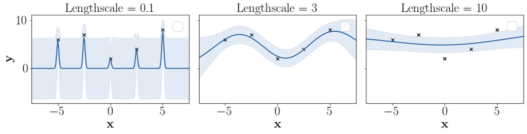

1. Gaussian processes (GP)
2. **$\to$** NOSTILL-GP (**NO**n-stationary **S**pace-**TI**me **L**atent **L**engthscale **GP**)

##### Stationarity of kernels

Stationary kernels $\to$ $K^S(\mathbf{x},\mathbf{x'}) = f(\mathbf{x}-\mathbf{x'})$

Non-stationary kernels $\to$ $K^{NS}(\mathbf{x},\mathbf{x'}) \ne f(\mathbf{x}-\mathbf{x'})$

Kernels

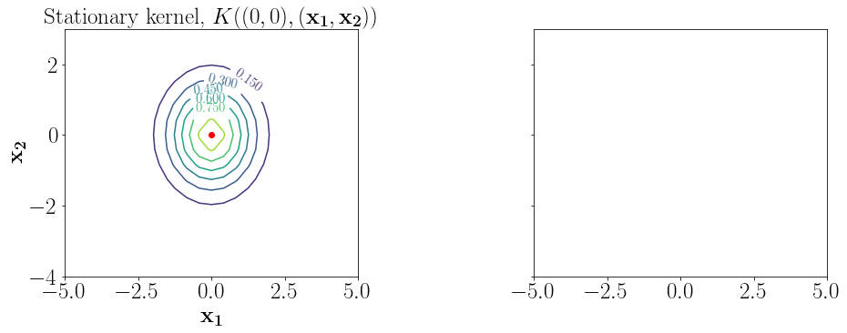

Kernels

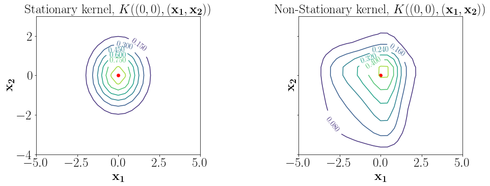

Kernels

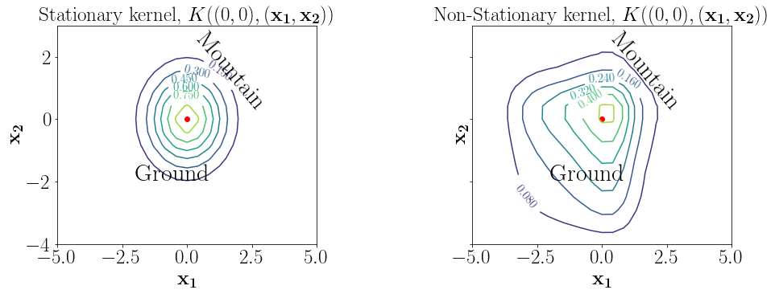

##### Introducing latent lengthscales

- location depended lengthscales
- $l_i$ for each $x_i$

#### Non-stationary (latent lengthscales) SE kernel (Paciorek et al.)

\begin{equation} l_{ij} = \sqrt{\frac{l_i^2+l_j^2}{2}}\\ \tau = \frac{(x_i-x_j)}{l_{ij}}\\ K^{NS}_{SE}(\tau) = \sigma_f^2\exp(-\tau^2)\;\;\;\;\text{not valid yet} \end{equation}

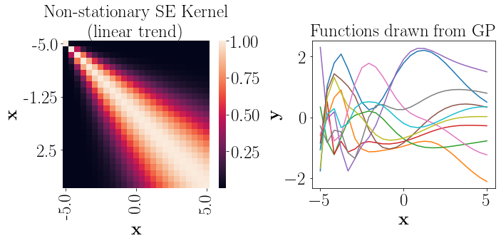

#### Seperable local lengthscale (LLS) kernel in 3D (Plagemann et al.)

\begin{align}\label{LLS} \Sigma_i &= \begin{bmatrix} ^{lat}l^2_i & 0 & 0\\ 0 & ^{long}l^2_i & 0\\ 0 & 0 & ^{t}l^2_i \end{bmatrix}\\ \tau&=\tau_{lat}\cdot\tau_{long}\cdot\tau_{t}\\ K^{NS}(\mathbf{x}_i, \mathbf{x}_j) &= \sigma_f^2|\Sigma_i|^{\frac{1}{4}}|\Sigma_j|^{\frac{1}{4}}\left|\frac{\Sigma_i+\Sigma_j}{2}\right|^{-\frac{1}{2}} K^S(\tau)\\ \end{align}

## Proposed model:

### Non-seperable NOSTILL-GP

#### Theorem 1: Non-seperable NOSTILL kernel is valid

\begin{align}\label{LLS} \tau &= f(\tau^s, \tau^t)\\ K^{NS}_{NOSTILL}(\mathbf{x}_i, \mathbf{x}_j) &= \sigma_f^2|\Sigma_i|^{\frac{1}{4}}|\Sigma_j|^{\frac{1}{4}}\left|\frac{\Sigma_i+\Sigma_j}{2}\right|^{-\frac{1}{2}} K^S(\tau)\\ \end{align}

### Complexity of NOSTILL-GP

- $n$ observations, $3n$ parameters (lengthscales)
- $n$ number of gradient calculations and updates

## Proposed methods for efficient learning of NOSTILL-GP

1. Modeling lengthscales with another GP
   - Intelligent latent location selection
     1. Information gain
     2. Pseudo inputs
2. Sparse GPs

## Proposed methods for efficient learning of NOSTILL-GP

1. **Modeling lengthscales with another GP**
   - Intelligent latent location selection
     1. Information gain
     2. Pseudo inputs
2. Sparse GPs

Modeling lengthscales with another GP

4-GP Model (3-local, 1-global)

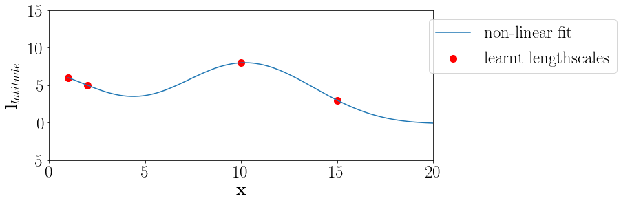

##### Modeling lengthscales with another GP - 4-GP model

### 4-GP model time-complexity

- ($n'<<n$) parameters (lengthscales), $n$ observations

##### Modeling lengthscales with another GP - 4-GP model

### 4-GP model time-complexity

- ($n'<<n$) parameters (lengthscales), $n$ observations
- $n'$ number of gradient calculations and updates

##### Modeling lengthscales with another GP - 4-GP model

### 4-GP model time-complexity

- ($n'<<n$) parameters (lengthscales), $n$ observations
- $n'$ number of gradient calculations and updates
- inference over $n$ points in $O(nn'^2)$ time

##### Modeling lengthscales with another GP - 4-GP model

### 4-GP model time-complexity

- ($n'<<n$) parameters (lengthscales), $n$ observations
- $n'$ number of gradient calculations and updates
- inference over $n$ points in $O(nn'^2)$ time

`Empirical time-complexity analysis missing in this work`

Modeling lengthscales with another GP

4-GP Model (3-local, 1-global)

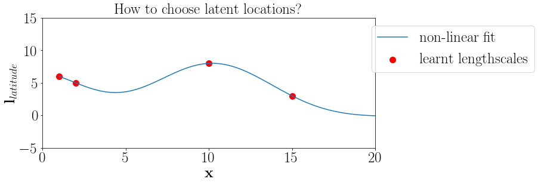

## Proposed methods for efficient learning of NOSTILL-GP

1. Modeling lengthscales with another GP
   - **Intelligent latent location selection**
     1. Information gain
     2. Pseudo inputs
2. Sparse GPs

## Proposed methods for efficient learning of NOSTILL-GP

1. Modeling lengthscales with another GP
   - Intelligent latent location selection
     1. **Information gain**
     2. Pseudo inputs
2. Sparse GPs

##### Intelligent latent location selection - 4-GP model

### Method 1: Maximizing Information gain (Krause et al.)

##### Intelligent latent location selection - 4-GP model

### Method 1: Maximizing Information gain (Krause et al.)

$\mathbf{l}-\text{known lengthscales}$, $\mathbf{l^*}-\text{unknown lengthscales}$

\begin{align} \text{Entropy} &\to argmax_l\;\mathcal{H}(l|\mathbf{l})\\ \\ \text{Mutual information} &\to argmax_l\;\mathcal{H}(l|\mathbf{l}) - \mathcal{H}(l|\mathbf{l^*}) \end{align}

Intelligent latent location selection - 4-GP model - Information gain

[figure not shown]

Intelligent latent location selection - 4-GP model - Information gain

[figure not shown]

##### Intelligent latent location selection - 4-GP model - Information gain

#### How do we get the covariance matrix?

1. Empirical covariance matrix
2. Stationary GP

##### Intelligent latent location selection - 4-GP model - Information gain

#### How do we get the covariance matrix?

1. **Empirical covariance matrix**
2. Stationary GP

##### Information gain algo - How do we get the covariance matrix?

#### Empirical covariance matrix

##### Information gain algo - How do we get the covariance matrix?

#### Empirical covariance matrix

##### Information gain algo - How do we get the covariance matrix?

#### Empirical covariance matrix

- Combine $X'_s$ (space) and $\mathbf{x}'_t$ (time) to get $X'$ (space-time)

##### Information gain algo - How do we get the covariance matrix?

#### Empirical covariance matrix

- Combine $X'_s$ (space) and $\mathbf{x}'_t$ (time) to get $X'$ (space-time)
- e.g. 4 latent locations (space) $\times$ 3 latent locations (time) = 12 latent locations (space-time)

##### Intelligent latent location selection - 4-GP model - Information gain

#### How do we get the covariance matrix?

1. Empirical covariance matrix
2. **Stationary GP**

##### Information gain algo - How do we get the covariance matrix?

#### Stationary GP

1. Fit stationary GP to $X \to \mathbf{y}$ (computationally inexpensive)

##### Information gain algo - How do we get the covariance matrix?

#### Stationary GP

1. Fit stationary GP to $X \to \mathbf{y}$ (computationally inexpensive)
2. Compute covariance matrix by evaluating $K^S(X,X)$

## Proposed methods for efficient learning of NOSTILL-GP

1. Modeling lengthscales with another GP
   - Intelligent latent location selection
     1. Information gain
     2. **Pseudo inputs**
2. Sparse GPs

#### Intelligent latent locations by pseudo-inputs

- We want to learn pseudo output $y'$ at pseudo locations $X'$.

#### Intelligent latent locations by pseudo-inputs

- We want to learn pseudo output $y'$ at pseudo locations $X'$.
- Posterior likelihood $p(\mathbf{y}|X',\mathbf{y}',X)$ should be maximized.

#### Intelligent latent locations by pseudo-inputs

- We want to learn pseudo output $y'$ at pseudo locations $X'$.
- Posterior likelihood $p(\mathbf{y}|X',\mathbf{y}',X)$ should be maximized.

Intelligent latent location selection - 4-GP model - Pseudo inputs

[figure not shown]

## Proposed methods for efficient learning of NOSTILL-GP

1. Modeling lengthscales with another GP
   - Intelligent latent location selection
     1. Information gain
     2. Pseudo inputs
2. **Sparse GPs**

##### Efficient learning of GPs - Sparse GPs

### Sparse GPs

- Melkumyan et al. propose an exact sparse kernel

\begin{align} K^{Sparse}(\tau) = \begin{cases} \left[\frac{2+cos(2\pi\tau)}{3}(1-\tau)+\frac{1}{2\pi}sin(2\pi\tau)\right] & \tau<1\\ 0 & \tau \ge 1 \end{cases} \end{align}

##### Efficient learning of GPs - Sparse GPs

### Sparse GPs

\begin{align} K^{NS}(\tau) = K^{NOSTILL}(\tau) \times K^{Sparse}(\tau) \end{align}

Efficient learning of GPs - Sparse GPs

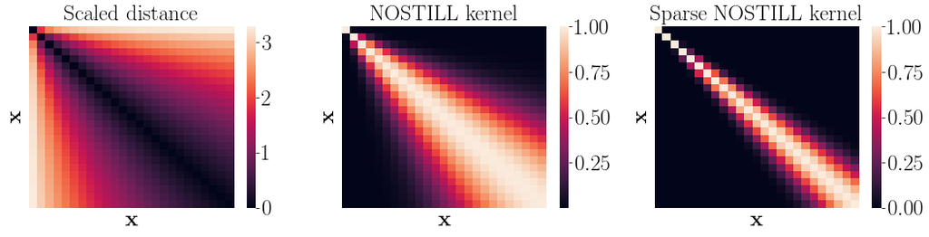

Efficient learning of GPs - Sparse GPs

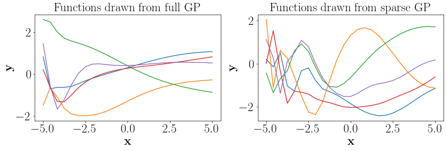

### Experiments

[output not shown]

#### Baselines

| Method | Abr. |
| --- | --- |
| Stationary GP | S |
| NS-Chunsheng | NS-C |
| Mixures of GPs | NS-MGP |
| Latent extention | NS-LEIS |

### Key insights - USA Ozone dataset

| Model | Latent location selection | RMSE |
| --- | --- | --- |
| NOSTILL | Information gain - Entropy | 2.82 |
| NOSTILL | Information gain - Mutual info. | 2.85 |
| NOSTILL | Pseudo inputs | 3.08 |
| NS-latent extension | -- | 4.01 |
| NS-Mixture of GPs | -- | 4.01 |
| NS-Chunsheng | -- | 7.27 |
| Stationary GP | -- | 7.39 |

### Key insights - Ireland Wind dataset

| Model | Latent location selection | RMSE |
| --- | --- | --- |
| NOSTILL | Information gain - Entropy | 2.34 |
| NOSTILL | Pseudo inputs | 2.72 |
| NOSTILL | Information gain - Mutual info. | 2.73 |
| Stationary GP | -- | 3.74 |
| NS-Chunsheng | -- | 3.76 |
| NS-Mixture of GPs | -- | 4.34 |
| NS-latent extension | -- | 4.46 |

### Key insights - Berkeley Intel Laboratory Temperature Data

| Model | Latent location selection | RMSE |
| --- | --- | --- |
| NOSTILL | Information gain - Entropy | 1.36 |
| NOSTILL | Pseudo inputs | 1.37 |
| NOSTILL | Information gain - Mutual info. | 1.41 |
| Stationary GP | -- | 1.53 |
| NS-latent extension | -- | 1.75 |
| NS-Chunsheng | -- | 2.42 |
| NS-Mixture of GPs | -- | 10.46 |